# HW1

Muammer Dolmaci

5/10/2021

## Libraries

```r
library(tidyverse)
#library(EVDS) #The API does not work properly
library(lubridate)
library(zoo)
```

```r
library(readxl) #To read Excel file
library(ggplot2) #To plot the graphs
#library(dplyr)
```

## Data

Due to the API of EVDS does not work properly, the data of EVDS can be uploaded manually.

```r
#set_evds_key("UQ7bM51uXF") #ID if the API will start to work again

myData <- read_excel("EVDS.xlsx")
View(myData)

colnames(myData) <- c("Date", "Electricity", "Workforce", "Credit")
str(myData)
```

```
## tibble[,4] [35 × 4] (S3: tbl_df/tbl/data.frame)
##  $ Date       : chr [1:35] "2018-05" "2018-06" "2018-07" "2018-08" ...
##  $ Electricity: num [1:35] 748237 766844 911801 859265 807078 ...
##  $ Workforce  : num [1:35] 32308 32454 32995 32807 32987 ...
##  $ Credit     : num [1:35] 2.30e+09 2.28e+09 2.34e+09 2.59e+09 2.49e+09 ...
```

There are 3 different types of data sets in the Excel file. These are listed below.

**TP.ELEKTUKETIM.TKT1 -** The electricity that is consumed. (MWh)

**TP.YISGUCU2.G2 -** The Workforce 15+ years. (Thousands People)

**TP.BO.SBIL01 -** The credit that is used. (Thousands TL)

The aim of this analysis is **to correlate the energy source, workforce and financial source of the industry**.

## Plot

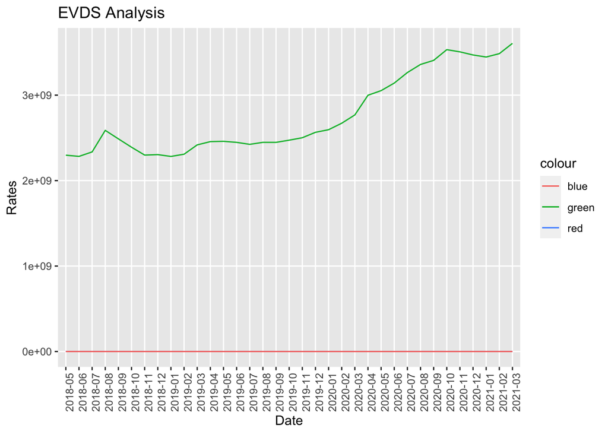

```r
myPlot <- ggplot(myData, aes(x=Date, group=1))+
    geom_line(aes(y=Electricity,color="red"))+
  geom_line(aes(y=Workforce, color="blue"))+
  geom_line(aes(y=Credit, color="green"))+
  theme(panel.grid.minor = element_blank(),
    axis.text.x = element_text(angle=90))+
   labs(x = "Date", y = "Rates",
              title = "EVDS Analysis")
myPlot
```

## Analysis

Companies need three base things to make production. This is the **energy source** which is consumed MWh electricity for this analysis, **workforce** which is thousands people above 15 years old for this analysis and **financial source** which is the used thousand liras credit for this analysis.

## Google Trends

When we include Google Trends in the game, we reached to these graphs.

```r
creditData <- read_excel("credit_gTrend.xlsx")
View(creditData)

colnames(creditData) <- c("Date", "Credit")
str(creditData)
```

```
## tibble[,2] [260 × 2] (S3: tbl_df/tbl/data.frame)
##  $ Date  : POSIXct[1:260], format: "2016-05-15" "2016-05-22" ...
##  $ Credit: num [1:260] 30 30 32 30 33 33 35 23 32 28 ...
```

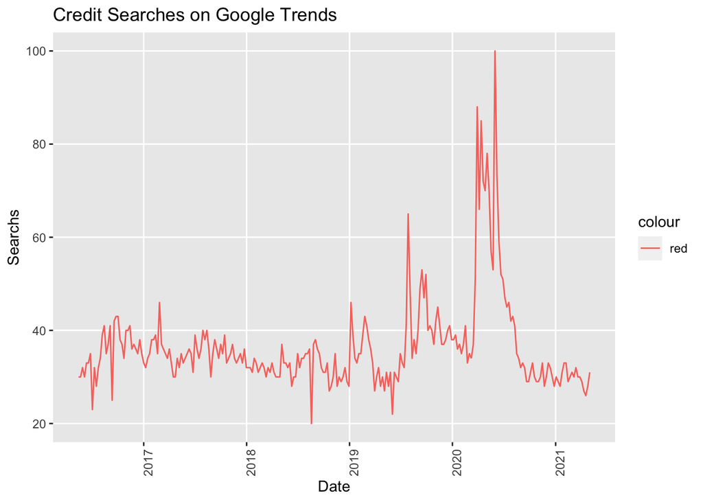

```r
creditPlot <- ggplot(creditData, aes(x=Date, group=1))+
    geom_line(aes(y=Credit,color="red"))+
  theme(panel.grid.minor = element_blank(),
    axis.text.x = element_text(angle=90))+
   labs(x = "Date", y = "Searchs",
              title = "Credit Searches on Google Trends")
creditPlot
```

## Correlation between EVDS and Google Trends

When we focused to *consumed credits*, we see that there is a significant increase in 2020. We can also saw similar things in the graph of EVDS. In 2020 there is an acceleration trend of consumed credit which is we expected.

Muammer DOLMACI